# REDCapTidieR: Extracting complex REDCap databases into tidy tables

# Summary

Capturing and storing electronic data is integral in the research world. [REDCap](https://projectredcap.org/) (Harris et al. 2009, 2019) offers a secure web application that lets users build databases and surveys with a robust front-end interface that can support data of any type, including data requiring compliance with standards for protected information.

Many REDCap users use the R programming language (R Core Team 2020) to extract and analyze their data. The [`REDCapR`](https://cran.r-project.org/web/packages/REDCapR/index.html) (Beasley 2023) and [`redcapAPI`](https://cran.r-project.org/web/packages/redcapAPI/index.html) (Nutter and Lane 2023) packages allow R users to extract data directly into their programming environment. While this works well for simple REDCap databases, it becomes cumbersome for complex databases, because the REDCap API outputs a “block matrix”–a single table with varied granularity levels, which conflicts with the “tidy data” framework (Wickham 2014) that advocates for standardized data organization.

To address this, we introduce `REDCapTidieR`, an open-source package that streamlines data extraction and restructures it into an intuitive format compatible with the tidy data principles. This facilitates seamless data analysis in R, especially for complex longitudinal studies.

While there are several tools available for REDCap data management, REDCapTidieR introduces a unique solution by transforming the challenging block matrix into a standardized tidy data structure that we term the “supertibble”. This approach not only aligns with good data science practice but also caters to databases of any complexity. By providing a suite of utility functions to work with the supertibble, REDCapTidieR provides a complete framework for extracting REDCap data designed with user-friendliness at its core.

# Statement of Need

As of 2023, the REDCap Consortium boasts nearly 3 million users across over 150 countries. REDCap databases range from single-instrument projects to complex builds that use both repeating instruments and repeating events. These data structures are needed to capture multiple items related to a specific visit, such as concomitant medications, or events that cannot be planned ahead of time, such as adverse events.

REDCap databases that contain repeating events and instruments require significant manual pre-processing, a major pain point for researchers and analysts. This is because the REDCap API returns a single table (Figure 1) that includes data from instruments that record data at different levels of granularity.

While there are a few existing REDCap tools (Table 1), `REDCapTidieR` occupies a unique space by providing analysts with a framework returns a tidy data structure regardless of the size or complexity of the extracted database. Although some of these tools also offer functions for data processing, such as the [`tidyREDCap`](https://raymondbalise.github.io/tidyREDCap/) (Balise et al. 2023) and [`REDCapDM`](https://ubidi.github.io/REDCapDM/index.html) (Carmezim et al. 2023) packages, only `REDCapTidieR` restructures the block matrix into an easy to use format.

`REDCapTidieR` is built with production readiness in mind. It builds upon `REDCapR`, which contains an excellent test suite, to make API calls, and includes an extensive automated test suite and ample documentation through a `pkgdown` site(https://chop-cgtinformatics.github.io/REDCapTidieR/index.html) (Hanna, Porter, and Kadauke 2023). It meets the rigorous requirements of the [OpenSSF Best Practices Badge](https://www.bestpractices.dev/en/projects/6845) (“OpenOpen Source Security Foundation_2023” 2023), which certifies open-source projects that adhere to criteria for delivering high-quality, robust, and secure software.

| Package | Exports from REDCap | Imports into REDCap | Tidy Reformatting | Extensive Test Suite |
| --- | --- | --- | --- | --- |
| redcapAPI | x | x |  | x |
| REDCapR | x | x |  | x |
| tidyREDCap | x |  |  |  |
| REDCapDM | x |  |  |  |
| REDCapTidieR | x |  | x | x |

Table 1: Comparative breakdown of the landscape for REDCap tools in R.

# Design

The `REDCapTidieR::read_redcap()` function leverages `REDCapR` to make API calls to query the data and metadata of a REDCap project and returns the supertibble (Figure 1). The supertibble, named after the [`tibble` package](https://tibble.tidyverse.org/) (Müller and Wickham 2023), is an alternative presentation of the data in which multiple tables are linked together in a single object in a fashion consistent with tidy data principles.

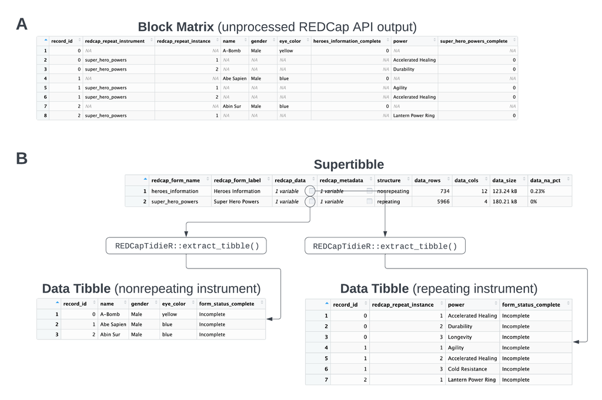

The REDCapTidieR Supertibble

Figure 1: The REDCapTidieR supertibble shown in the Data Viewer of the RStudio IDE. The “Superhero database” (Lingen 2023) contains two instruments, one nonrepeating and one repeating. A. The REDCap API outputs a “Block Matrix”. Note an abundance of `NA` values, which do not represent missing values but rather fields that do not apply due to the data structure. B. The `read_redcap()` function returns a “Supertibble”. Note that each row represents one instrument, identified by the `redcap_form_name` column. The `redcap_data` column is a list column that links to tibbles containing the data from a specific instrument. The Data Viewer allows drilling down into individual tibbles by clicking on the table icon, allowing for rapid and intuitive data exploration without any preprocessing. Since each instrument has a consistent granularity, these tibbles can be tidy. Two data tibbles are shown, one from a nonrepeating and one from a repeating instrument. Note the differences in granularity between the instruments.

`REDCapTidieR` provides utility functions to work with the supertibble, all designed to work with the R pipe operator `|>`. The `extract_tibble()` function takes a supertibble object and returns a specific data tibble. The `make_labelled()` function leverages the `labelled` package (Larmarange 2023) to apply variable labels to the supertibble. The `add_skimr_metadata()` function uses the `skimr` package (Waring et al. 2023) to add summary statistics. Using the `write_redcap_xlsx()` function, which leverages the `openxlsx2` (*Openxlsx2: Read, Write and Edit ’Xlsx’ Files* 2023) package, users can easily export an the supertibble into a collaborator-friendly Excel document, in which each Excel sheet contains the data for an instrument.

`REDCapTidieR` cannot be used to write data to a REDCap project. We refer the reader to an excellent guide of how to accomplish this using `REDCapR` (Beasley and Balise 2023).

# Installation

`REDCapTidieR` is available on [GitHub](https://github.com/CHOP-CGTInformatics/REDCapTidieR) and [CRAN](https://cran.r-project.org/web/packages/REDCapTidieR/index.html) and works on all major operating systems.

# Acknowledgements

We would like to thank Will Beasley, Paul Wildenhain, and Jan Marvin for their feedback and support in development.

This package was developed by the [Cell and Gene Therapy Informatics Team](https://www.chop.edu/centers-programs/cell-and-gene-therapy-informatics-team/our-team) of the [Children’s Hospital of Philadelphia](https://www.chop.edu).

# Conflict of interest

The authors declare no financial conflicts of interest.

# References

Balise, Raymond, Gabriel Odom, Anna Calderon, Layla Bouzoubaa, Wayne DeFreitas, and Kyle Grealis. 2023. *tidyREDCap: Helper Functions for Working with ’REDCap’ Data*. https://raymondbalise.github.io/tidyREDCap/index.html.

Beasley, Will. 2023. *REDCapR: Interaction Between r and REDCap*.

Beasley, Will, and Raymond Balise. 2023. *Writing to a REDCap Project*. https://ouhscbbmc.github.io/REDCapR/articles/workflow-write.html.

Carmezim, João, Judith Peñafiel, Pau Satorra, Esther García, Natàlia Pallarés, and Cristian Tebé. 2023. *REDCapDM: ’REDCap’ Data Management*. https://ubidi.github.io/REDCapDM/.

Hanna, Richard, Ezra Porter, and Stephan Kadauke. 2023. *REDCapTidieR*. https://chop-cgtinformatics.github.io/REDCapTidieR/index.html.

Harris, Paul A., Robert Taylor, Brenda L. Minor, Veida Elliott, Michelle Fernandez, Lindsay O’Neal, Laura McLeod, et al. 2019. “The REDCap Consortium: Building an International Community of Software Platform Partners.” *Journal of Biomedical Informatics* 95: 103208. https://doi.org/https://doi.org/10.1016/j.jbi.2019.103208.

Harris, Paul A., Robert Taylor, Robert Thielke, Jonathon Payne, Nathaniel Gonzalez, and Jose G. Conde. 2009. “Research Electronic Data Capture (REDCap)—a Metadata-Driven Methodology and Workflow Process for Providing Translational Research Informatics Support.” *Journal of Biomedical Informatics* 42 (2): 377–81. https://doi.org/https://doi.org/10.1016/j.jbi.2008.08.010.

Larmarange, Joseph. 2023. *Labelled: Manipulating Labelled Data*. https://larmarange.github.io/labelled/.

Lingen, Jeroen ter. 2023. *Superhero Database*. https://www.superherodb.com/.

Müller, Kirill, and Hadley Wickham. 2023. *Tibble: Simple Data Frames*.

Nutter, Benjamin, and Stephen Lane. 2023. *redcapAPI: Accessing Data from REDCap Projects Using the API*. https://doi.org/10.5281/zenodo.11826.

“OpenOpen Source Security Foundation_2023.” 2023. *Open Source Security Foundation*. The Linux Foundation. https://openssf.org/.

*Openxlsx2: Read, Write and Edit ’Xlsx’ Files*. 2023. https://janmarvin.github.io/openxlsx2/.

R Core Team. 2020. *R: A Language and Environment for Statistical Computing*. Vienna, Austria: R Foundation for Statistical Computing. https://www.R-project.org/.

Waring, Elin, Michael Quinn, Amelia McNamara, Eduardo Arino de la Rubia, Hao Zhu, and Shannon Ellis. 2023. *Skimr: Compact and Flexible Summaries of Data*. https://docs.ropensci.org/skimr/ (website).

Wickham, Hadley. 2014. “Tidy Data.” *Journal of Statistical Software* 59 (10): 1–23. https://doi.org/10.18637/jss.v059.i10.